# 🎯 PHÂN TÍCH CÁC YẾU TỐ ẢNH HƯỞNG ĐẾN KHẢ NĂNG RỜI ĐI (EXIT) CỦA NGÂN HÀNG

## 2, Multi Models

```python
data_for_ml = data.copy()

# Chỉ lấy các cột cần thiết
data_for_ml = data_for_ml.drop([
    'address','last_active_date','last_transaction_month','created_date',
    'cluster_group','age', 'gender','monthly_ir','balance',
    'engagement_score','risk_score'],
    axis = 1)

data_for_ml.head(5)
```

|  | credit_sco | occupation | tenure_ye | nums_card | nums_service | active_member | exit | customer_segment | loyalty_level | digital_behavior | risk_segment | age_group | balance_to_income_ratio | balance_segment | income_segment | total_product | engagescr_per_prod | engagescr_risk |
| --- | --- | --- | --- | --- | --- | --- | --- | --- | --- | --- | --- | --- | --- | --- | --- | --- | --- | --- |
| 0 | 725 | Chủ Doanh nghiệp nhỏ | 0 | 4 | 8 | True | 0 | Priority | Bronze | mobile | Low | Gen X | 1.465339 | Low | Elite | 12 | 7.500000 | 3.2310 |
| 1 | 689 | Nội trợ/Sinh viên | 3 | 3 | 2 | True | 0 | Mass | Gold | mobile | Low | Gen X | 0.385483 | Low | Low | 5 | 12.600000 | 16.7832 |
| 2 | 702 | Chủ Doanh nghiệp nhỏ | 4 | 2 | 8 | False | 0 | Priority | Silver | offline | Low | Gen X | 2.797539 | Middle | Elite | 10 | 3.600000 | 4.8348 |
| 3 | 766 | Chủ Doanh nghiệp nhỏ | 3 | 4 | 3 | False | 0 | Priority | Bronze | offline | Low | Gen X | 0.640703 | Low | Elite | 7 | 3.285714 | 5.0255 |
| 4 | 677 | Giáo viên/Giảng viên | 2 | 4 | 3 | False | 0 | Emerging | Bronze | offline | Low | Boomers | 1.621297 | Low | High | 7 | 3.285714 | 6.7666 |

```python
# Xử lý các cột kiểu object và category
data_for_ml['active_member'] = data_for_ml['active_member'].astype(int)

for col in ['occupation','digital_behavior','customer_segment'] :
    data_for_ml[col] = data_for_ml[col].astype('category')

# Xử lý các cột category có giá trị theo kiểu phân cấp
balance_map = {'Low': 0, 'Middle': 1, 'High': 2, 'Elite': 3}
loyalty_map = {'Bronze': 0, 'Silver': 1, 'Gold': 2}
risk_map = {'Low': 0, 'Medium': 1}
customer_map = {'Mass' : 0,'Emerging' : 1, 'Affluent' : 2, 'Priority' : 3 }


# Map vào bảng
data_for_ml['balance_segment'] = data_for_ml['balance_segment'].map(balance_map)
data_for_ml['loyalty_level'] = data_for_ml['loyalty_level'].map(loyalty_map)
data_for_ml['risk_segment'] = data_for_ml['risk_segment'].map(risk_map)
data_for_ml['customer_segment'] = data_for_ml['customer_segment'].map(customer_map).astype(int)
```

```python
data_for_ml.info()
```

```
<class 'pandas.core.frame.DataFrame'>
RangeIndex: 80000 entries, 0 to 79999
Data columns (total 18 columns):
 #   Column                   Non-Null Count  Dtype
---  ------                   --------------  -----
 0   credit_sco               80000 non-null  int64
 1   occupation               80000 non-null  category
 2   tenure_ye                80000 non-null  int64
 3   nums_card                80000 non-null  int64
 4   nums_service             80000 non-null  int64
 5   active_member            80000 non-null  int64
 6   exit                     80000 non-null  int64
 7   customer_segment         80000 non-null  int64
 8   loyalty_level            80000 non-null  int64
 9   digital_behavior         80000 non-null  category
 10  risk_segment             80000 non-null  int64
 11  age_group                80000 non-null  category
 12  balance_to_income_ratio  80000 non-null  float64
 13  balance_segment          80000 non-null  category
 14  income_segment           80000 non-null  category
 15  total_product            80000 non-null  int64
 16  engagescr_per_prod       80000 non-null  float64
 17  engagescr_risk           80000 non-null  float64
dtypes: category(5), float64(3), int64(10)
memory usage: 8.3 MB
```

```python
data_for_ml.head(5)
```

|  | credit_sco | occupation | tenure_ye | nums_card | nums_service | active_member | exit | customer_segment | loyalty_level | digital_behavior | risk_segment | age_group | balance_to_income_ratio | balance_segment | income_segment | total_product | engagescr_per_prod | engagescr_risk |
| --- | --- | --- | --- | --- | --- | --- | --- | --- | --- | --- | --- | --- | --- | --- | --- | --- | --- | --- |
| 0 | 725 | Chủ Doanh nghiệp nhỏ | 0 | 4 | 8 | 1 | 0 | 3 | 0 | mobile | 0 | Gen X | 1.465339 | 0 | Elite | 12 | 7.500000 | 3.2310 |
| 1 | 689 | Nội trợ/Sinh viên | 3 | 3 | 2 | 1 | 0 | 0 | 2 | mobile | 0 | Gen X | 0.385483 | 0 | Low | 5 | 12.600000 | 16.7832 |
| 2 | 702 | Chủ Doanh nghiệp nhỏ | 4 | 2 | 8 | 0 | 0 | 3 | 1 | offline | 0 | Gen X | 2.797539 | 1 | Elite | 10 | 3.600000 | 4.8348 |
| 3 | 766 | Chủ Doanh nghiệp nhỏ | 3 | 4 | 3 | 0 | 0 | 3 | 0 | offline | 0 | Gen X | 0.640703 | 0 | Elite | 7 | 3.285714 | 5.0255 |
| 4 | 677 | Giáo viên/Giảng viên | 2 | 4 | 3 | 0 | 0 | 1 | 0 | offline | 0 | Boomers | 1.621297 | 0 | High | 7 | 3.285714 | 6.7666 |

```python
from sklearn.model_selection import train_test_split

# Định nghĩa hàm chia dữ liệu thành bộ train và test
def split_data(rows : int,df):
    x = df.drop('exit', axis = 1)[0:rows]
    y = df['exit'][0:rows]

    # Chia thành tập train và test
    x_train, x_test, y_train, y_test = train_test_split(x, y, test_size= 0.2, random_state= 42)
    return x_train, x_test, y_train, y_test

# Chỉ đánh giá 10000 mẫu để tiết kiệm tài nguyên
x_train, x_test, y_train, y_test = split_data(20000,data_for_ml)
```

```python
from lazypredict.Supervised import LazyClassifier

# Định nghĩa lazypredict và chạy thử các model
clf = LazyClassifier(verbose = 0, ignore_warnings= True, custom_metric= None)
models , predictions = clf.fit(x_train, x_test, y_train, y_test)

models
```

| Model | Accuracy | Balanced Accuracy | ROC AUC | F1 Score | Precision | Recall | Time Taken |
| --- | --- | --- | --- | --- | --- | --- | --- |
| QuadraticDiscriminantAnalysis | 0.70575 | 0.738592 | 0.805664 | 0.736851 | 0.827811 | 0.70575 | 0.089923 |
| NearestCentroid | 0.71675 | 0.734635 | 0.812274 | 0.745752 | 0.824084 | 0.71675 | 0.056330 |
| GaussianNB | 0.71575 | 0.728399 | 0.801998 | 0.744615 | 0.820390 | 0.71575 | 0.043477 |
| BernoulliNB | 0.76875 | 0.675706 | 0.796364 | 0.779174 | 0.793902 | 0.76875 | 0.041831 |
| DecisionTreeClassifier | 0.77400 | 0.629376 | 0.629376 | 0.773884 | 0.773769 | 0.77400 | 0.166917 |
| LogisticRegression | 0.82775 | 0.624663 | 0.845002 | 0.804732 | 0.802862 | 0.82775 | 0.081726 |
| LGBMClassifier | 0.82500 | 0.624502 | 0.832131 | 0.803108 | 0.799776 | 0.82500 | 0.420214 |
| ExtraTreeClassifier | 0.76800 | 0.621083 | 0.621083 | 0.768236 | 0.768474 | 0.76800 | 0.048073 |
| KNeighborsClassifier | 0.80450 | 0.617499 | 0.749230 | 0.789109 | 0.781160 | 0.80450 | 0.708658 |
| AdaBoostClassifier | 0.82175 | 0.615348 | 0.836910 | 0.798112 | 0.794445 | 0.82175 | 0.851212 |
| XGBClassifier | 0.81225 | 0.615118 | 0.822276 | 0.792750 | 0.785701 | 0.81225 | 0.373015 |
| RandomForestClassifier | 0.81250 | 0.614250 | 0.812575 | 0.792601 | 0.785628 | 0.81250 | 2.891185 |
| ExtraTreesClassifier | 0.80025 | 0.610284 | 0.795519 | 0.784444 | 0.775939 | 0.80025 | 1.744906 |
| LabelPropagation | 0.77500 | 0.608021 | NaN | 0.769241 | 0.764337 | 0.77500 | 16.104151 |
| LabelSpreading | 0.77700 | 0.607719 | NaN | 0.770336 | 0.764821 | 0.77700 | 25.193345 |
| CalibratedClassifierCV | 0.82375 | 0.605849 | 0.844939 | 0.795658 | 0.795048 | 0.82375 | 0.270911 |
| BaggingClassifier | 0.80900 | 0.602898 | 0.781077 | 0.786773 | 0.779190 | 0.80900 | 0.835076 |
| Perceptron | 0.79475 | 0.592591 | 0.709534 | 0.775603 | 0.765664 | 0.79475 | 0.055540 |
| LinearDiscriminantAnalysis | 0.81975 | 0.588057 | 0.835601 | 0.786335 | 0.786791 | 0.81975 | 0.203537 |
| LinearSVC | 0.82150 | 0.585047 | 0.844957 | 0.785805 | 0.789099 | 0.82150 | 0.121380 |
| SGDClassifier | 0.81900 | 0.575333 | 0.805203 | 0.780152 | 0.783793 | 0.81900 | 0.121130 |
| RidgeClassifierCV | 0.82000 | 0.572372 | 0.835642 | 0.779109 | 0.785356 | 0.82000 | 0.121922 |
| RidgeClassifier | 0.82000 | 0.572372 | 0.835605 | 0.779109 | 0.785356 | 0.82000 | 0.058544 |
| SVC | 0.81950 | 0.571042 | 0.804629 | 0.778239 | 0.784292 | 0.81950 | 12.765395 |
| PassiveAggressiveClassifier | 0.74400 | 0.530172 | 0.662880 | 0.728380 | 0.715875 | 0.74400 | 0.060496 |
| DummyClassifier | 0.81200 | 0.500000 | 0.500000 | 0.727753 | 0.659344 | 0.81200 | 0.033399 |

NHẬN XÉT :

## 3, Building Model

### 3.1, Sử Dụng RandomizedSearchCV để tìm bộ tham số tối ưu

```python
# Lấy 50000 dòng đầu để tối ưu thời gian
data_for_ml[:50000].exit.value_counts()
```

| exit | count |
| --- | --- |
| 0 | 41000 |
| 1 | 9000 |

**dtype:** int64

```python
from xgboost import XGBClassifier
from lightgbm import LGBMClassifier
from sklearn.model_selection import StratifiedKFold,RandomizedSearchCV
from scipy.stats import randint

# Định nghĩa mô hình
lgbmc = LGBMClassifier(random_state=42, verbosity = -1)

# Lấy số lượng mẫu đủ lớn
x_train, x_test, y_train, y_test = split_data(50000,data_for_ml)

# Thiết lập số Fold chia
skf = StratifiedKFold(n_splits=5, shuffle=True, random_state=42)

# Định nghĩa tham số
param_dist = {
        'n_estimators' : [100,200,500],
        'learning_rate' : [0.01,0.05,0.1],
        'scale_pos_weight' : [4],
        'num_leaves' : randint(30,128),
        'max_depth' : [4,5,6],
        'min_child_samples' : randint(30,100),
        'colsample_bytree': [0.4, 0.5, 0.6,0.7,0.8]
    }

random_search = RandomizedSearchCV(
    estimator= lgbmc,
    param_distributions=param_dist,
    n_iter=60,
    cv=skf,
    scoring='balanced_accuracy',
    verbose = 0,
    n_jobs= -1
)

random_search.fit(x_train,y_train)

print(f'Best_score : {random_search.best_score_}')
for key,value in random_search.best_params_.items():
    print(f'{key} : {value}')
```

```
Best_score : 0.7729185650472541
colsample_bytree : 0.6
learning_rate : 0.05
max_depth : 5
min_child_samples : 67
n_estimators : 100
num_leaves : 118
scale_pos_weight : 4
```

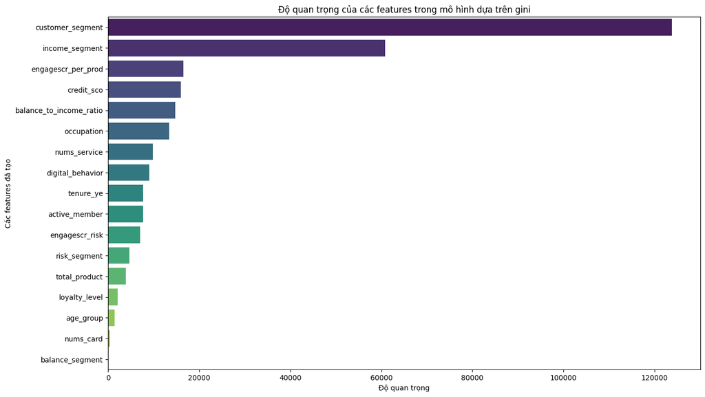

```python
# Lấy ra bộ tham số tốt nhất
best_lgbm = random_search.best_estimator_

# Lấy danh sách cột và danh sách các features quan tr
features = x_train.columns
importances = best_lgbm.booster_.feature_importance(importance_type='gain')

# Tạo bảng
df_imp = pd.DataFrame({'Features' : features,'Importances': importances})
df_imp = df_imp.sort_values(by='Importances',ascending=False)

# Vẽ biểu đồ
plt.figure(figsize=(15,9))

sns.barplot(data=df_imp,x='Importances',y='Features',palette='viridis')
plt.title('Độ quan trọng của các features trong mô hình dựa trên gini')
plt.xlabel('Độ quan trọng')
plt.ylabel('Các features đã tạo')

plt.show()
```

NHẬN XÉT

### 3.2, Sử Dụng Bộ Tham Số Tốt Nhất Để Làm Mô Hình Dự Đoán

```python
x_test.shape
```

```
(10000, 17)
```

```python
# Dự đoán trên bộ test (Nhãn 0 : Không rời bỏ , Nhãn 1 : Rời bỏ)
y_pred = best_lgbm.predict(x_test)

# Dự đoán xác suất
y_pred_proba = best_lgbm.predict_proba(x_test)[:,1]


#In bảng dự đoán
df_res = pd.DataFrame({'Thực tế': y_test,'Dự đoán' : y_pred, 'Xác suất Churn' : y_pred_proba})
df_res.head(20)
```

|  | Thực tế | Dự đoán | Xác suất Churn |
| --- | --- | --- | --- |
| 33553 | 0 | 0 | 0.264926 |
| 9427 | 0 | 0 | 0.163852 |
| 199 | 0 | 1 | 0.511543 |
| 12447 | 0 | 1 | 0.709931 |
| 39489 | 0 | 1 | 0.659076 |
| 42724 | 0 | 0 | 0.006422 |
| 10822 | 1 | 1 | 0.669110 |
| 49498 | 0 | 1 | 0.617362 |
| 4144 | 0 | 0 | 0.073474 |
| 36958 | 0 | 0 | 0.004088 |
| 43106 | 0 | 1 | 0.765622 |
| 38695 | 0 | 0 | 0.087158 |
| 6188 | 1 | 1 | 0.804493 |
| 1414 | 1 | 1 | 0.735512 |
| 18471 | 0 | 0 | 0.377163 |
| 29282 | 0 | 1 | 0.839132 |
| 15177 | 0 | 0 | 0.022118 |
| 34304 | 0 | 0 | 0.001520 |
| 12609 | 0 | 0 | 0.417419 |
| 12144 | 0 | 0 | 0.384538 |

```python
from sklearn.metrics import classification_report
# In ra các metrics
print(classification_report(y_test,y_pred))
```

```
              precision    recall  f1-score   support

           0       0.95      0.73      0.83      8207
           1       0.40      0.81      0.54      1793

    accuracy                           0.75     10000
   macro avg       0.67      0.77      0.68     10000
weighted avg       0.85      0.75      0.77     10000
```

NHẬN XÉT :

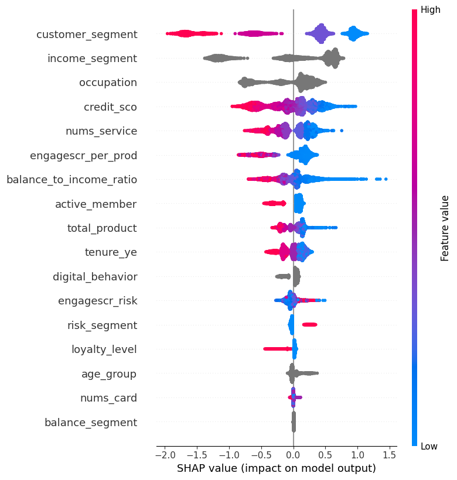

```python
import shap

# Tạo cây giải thích
explainer = shap.TreeExplainer(best_lgbm)

# Tính toán giá trị SHAP cho tập X_test
shap_values = explainer.shap_values(x_test)

# Vẽ biểu đồ Summary Plot
shap.summary_plot(shap_values, x_test)
```

NHẬN XÉT :

- Có thể thấy được rằng customer_segment đem lại tín hiệu phân loại rất mạnh khi mà phân khúc càng cao thì mô hình lại càng chắc chắn là không rời đi => Feature then chốt nhất,ngân hàng cần tập trung nguồn lực trong việc tối ưu feature này
- Bên cạnh đó , điểm tham gia trên mỗi sản phẩm(engagescr_per_prod) và điểm tín dụng(credit_scr) cũng củng cố cho khả năng phân loại của mô hình

### 3.3, Phân Tích Ngưỡng (Threshold) Tối Ưu && ROC_AUC_Curve

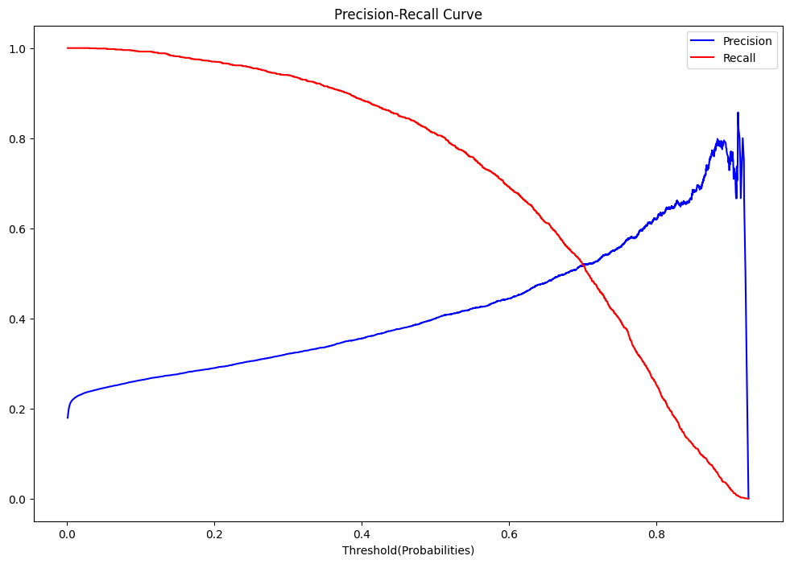

```python
from sklearn.metrics import precision_recall_curve
import numpy as np

# Lấy precision, recall và thresholds
precisions, recalls ,thresholds = precision_recall_curve(y_test,y_pred_proba)

# Vẽ biểu đồ
plt.figure(figsize=(12,8))

plt.plot(thresholds,precisions[:-1],'b',label = 'Precision')
plt.plot(thresholds,recalls[:-1],'r-',label = 'Recall')
plt.title('Precision-Recall Curve')
plt.legend(loc = 'upper right')
plt.xlabel('Threshold(Probabilities)')
plt.show()
```

NHẬN XÉT :

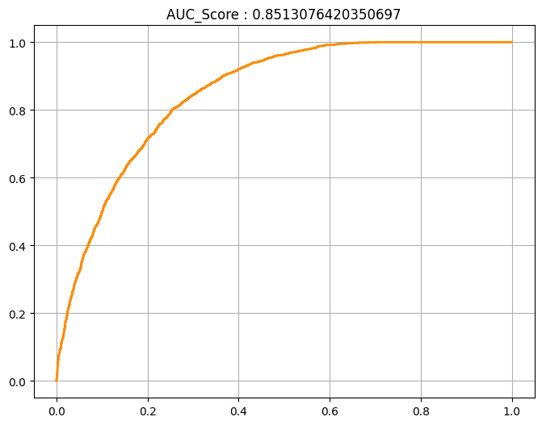

```python
from sklearn.metrics import roc_curve, roc_auc_score
import matplotlib.pyplot as plt

# Tính diện tích auc
auc_score = roc_auc_score(y_test, y_pred_proba)

# Lấy các giá trị false positive và true positive
fpr, tpr, _ = roc_curve(y_test, y_pred_proba)

# 3. Vẽ biểu đồ
plt.figure(figsize=(8, 6))
plt.plot(fpr, tpr, color='darkorange',lw =2)
plt.grid()
plt.title(f'AUC_Score : {auc_score}')
plt.show()
```

NHẬN XÉT :

- AUC = 0.85 cho thấy mô hình đã có khả năng phân loại tốt và có tính ứng dụng thực tế rất cao
- Việc biểu đồ ROC curve khá mượt mà cho thấy rằng các features đã cung cấp tín hiệu phân loại rất tốt cho mô hình